# 10 Reporting Reproducible Research

01 May, 2018

## Overview

## Lesson Structure

In this session we'll cover reproducible reporting in RMarkdown.

Specifically, we'll cover:

- Calculating effect sizes from the *r* and *d* families
- Evaluating evidence for the null hypothesis
- Calculating 95% confidence intervals
- Simulation for understanding research practices
- Data and code archiving, and pre-registration on the [Open Science Framework](https://osf.io/)

## Getting Started

As always, we first need to load the `tidyverse` set of packages for this Chapter. We'll also need the **sjstats**, **effsize**, and **TOSTER** packages. The first two for effect sizes, and the last for doing equivalence tests.

```r
# load packages
library(tidyverse)
library(sjstats)
library(effsize)
library(TOSTER)
```

## Creating Reproducible Documents

### Creating a Reproducible Report

- R makes your analysis procedure clear - you write in code what you did!
- R makes re-calculating analyses quick and easy!
- Papers, presentations, or blog posts rely on you reporting statistics. Transcription introduces human error. Let's avoid this!
- If I can read your code, I can implement your methods easily

## Creating Reproducible Documents

### R Notebooks and Markdown Documents

R Markdown documents are more flexible:

- Doesn't update rendered document on saving
- No live preview
- **But**, flexible outputs; HTML, Word, PDF

Really, it just takes changing the document type from a notebook to an html/word document. The code and text etc. remains the same! You just knit the file each time to render it.

## Creating Reproducible Documents

### How to make an RMarkdown file…

[figure not shown]

## Creating Reproducible Documents

### How to make an RMarkdown file…

Choose your output type; Documents (HTML/Word/PDF), presentations (this one; ioslides), etc.

[figure not shown]

## Creating Reproducible Documents

### How to make an RMarkdown file…

The same principles apply to all documents; name it and put your name in there.

e.g. `test_html_document`: title on rendering the document.

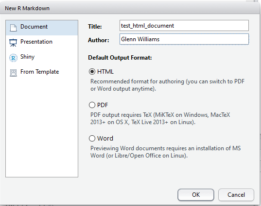

## Creating Reproducible Documents

### How to make an RMarkdown file…

- Save the document somewhere
- change code and text; code chunks for code, plain text for writing.
- formatting text is done via markdown, e.g. **bold text**
- plenty of cheat sheets out there – see this chapter for that!

## Creating Reproducible Documents

### How to make an RMarkdown file…

- Knit the document to make it render
- Errors in code = fail to knit; but tells you the line where it fails!
- See output in RStudio, or double click output (e.g. HTML document)

## Creating Reproducible Documents

### How to make an RMarkdown file…

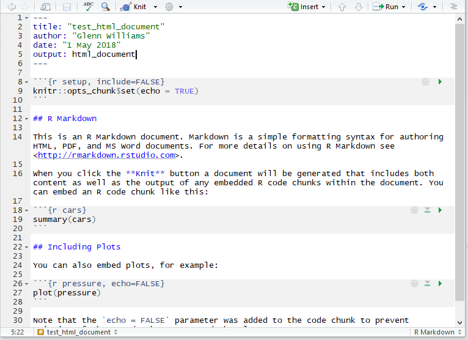

## Folder Structure for Reproducible Analyses

- 1 experiment, 1 folder
- subfolders for different tasks; Data, Analysis, Outputs
- use **relative** file paths to read data from other folders, e.g.

```r
data <- read_csv("../Data/raw_data.csv")
```

Say we're in the **Analysis** folder, this goes up one out of that folder, then looks in the **Data** folder, finally reading in the **raw_data.csv** file.

## Folder Structure for Reproducible Analyses

- Edit your RMarkdown file in the **Analysis** folder, then…
- Render it in the **Outputs** folder by creating and running another R script (not RMarkdown, R).

This just needs the following line:

```r
rmarkdown::render('test_html_document.Rmd',
                  output_file = '../Output/test_html_document.html'
                  )
```

- Real example in your **lesson_materials** folder

## Creating Reproducible Documents

### Tables

How to make it a table from a data frame? Kable it!

```r
# make example data
tooth_dat <- ToothGrowth %>% group_by(supp) %>% summarise(mean_len = mean(len))
# print table
library(knitr)
kable(tooth_dat)
```

| supp | mean_len |
| --- | --- |
| OJ | 20.66333 |
| VC | 16.96333 |

It's that simple. There are more ways to customise, but details of that are online.

## Creating Reproducible Documents

### Using R Markdown Templates

- There are several document templates out there. Check GitHub and google for examples
- Papaja is for 6th Edition APA paper templates
- When installing from GitHub, you will need devtools installed

```r
# install.packages("devtools")
devtools::install_github("crsh/papaja")
```

*We won't use this here, but it's good to know about templates*.

## Creating Reproducible Documents

### Using R Markdown Templates

With any document, you can make your own reference file, e.g. references.bib - typically used for LaTeX documents - any reference manager should make a .bib file for you. - put the .bib file in the same folder as your Rmarkdown script, load in the YAML header, e.g.

```
---
title: "Sample Document"
output: html_document
bibliography: bibliography.bib
---
```

## Open Science

If you have reproducible analyses, you may as well go the whole way.

- **Reproducible reports**: code included and used for analyses/plots
- **Pre-prints**: repository, e.g. [PsyAr\(\chi\)iv](https://psyarxiv.com/) – get instant feedback, open to anyone to read.
- **Pre-registration and registered reports**: full analysis plan (including outliers, \(\alpha\)-level, sample size justification) and hypotheses. Distinguishes exploratory from confirmatory research, formalises type-I error rate. AsPredicted.org/OSF for this. **Let me convince you about this!**

## Open Science

- **Open access publishing**: Let tax payers see the result of their taxes.
- **Open materials, data, and code**: Share everything. You have back ups, can check errors, or learn from others.

Crucial: **README** file (can be plain text) explaining all variables and how to understand data etc.

## What to Report

- We've covered inferential and descriptive statistics, as well as plots
- Want to know if we should *care* if something is significant:
- Effect sizes: can be raw or standardised, raw is provided by parameter estimates, so we'll look at standardised
- Measure of uncertainty around estimates: e.g. 95% confidence interval from model fit
- Whether the null is evidence of absence

## Effect Sizes

Why report standardised effect size?

- Allows comparison across studies/designs
- Crucial for meta-analysis
- Useful for analytic power analyses (i.e. not simulation-based (although possible here too))

We saw \(r\) and \(r^2\) in correlation. But what about *t*-tests and ANOVA?

- **sjstats** package for ANOVA and linear regression models
- **effsize** package for *t*-tests

## Cohen's d and Pearson's r

2 families of effect sizes: \(d\) and \(r\)

\(d\) = **standardised mean differences**. These go from 0 (no effect) to \(\infty\) (infinity) - e.g. Cohen's \(d\) = differences between group scores divided by pooled \(SD\)

Different forms, e.g.

- *d*<sub>z</sub> for within-subjects designs
- *d*<sub>av</sub> for within-subjects designs corrected for correlations between measures
- Hedge's *g* for unbiased form (don't know population \(SD\)). Better for small sample sizes, and doesn't overstate effect sizes as much.

The choice is up to you!

## Cohen's d and Pearson's r

2 families of effect sizes: \(d\) and \(r\)

\(r\) = **strength of association between variables**. Goes from 0 (no association) to 1 (complete association). Sum of squared differences between observations and the mean.

Different forms, e.g.

- \(\eta^2\) (eta squared) for more than 2 sets of observations;
- \(\omega^2\) (omega squared) corrects due to not knowing population variance. Better for small samples/many levels.
- \(\epsilon^2\) (epsilon squared), possibly the least biased.

Have partial forms (which don't sum to 100%) to explain variance explained by 1 factor independently.

## Cohen's d and Pearson's r

- Cohen's \(d\) is typically less biased than Pearson's \(r\) for uneven sample sizes
- But \(r\) is typically easier to understand.
- For both, avoid benchmarks in planning your studies! Use the literature, but beware of **publication bias** which overstates effect sizes

## Effect sizes

### Cohen's d and Hedge's g

Make some data for a *t*-test

```r
set.seed(5)
ind_t_data <- tibble(
  dv = c(rnorm(n = 10000, mean = 100, sd = 10),
         rnorm(n = 10000, mean = 99, sd = 10)),
  id = c(rep("a", 10000), rep("b", 10000))
  )
ind_t_data %>% group_by(id) %>% summarise(mean_dv = mean(dv))
```

```
## # A tibble: 2 x 2
##   id    mean_dv
##   <chr>   <dbl>
## 1 a       100
## 2 b        98.9
```

## Effect sizes

### Cohen's d and Hedge's g

Look at the reults of an independent-sample *t*-test. Do we really care? That mean difference was tiny!

```r
t.test(dv ~ id, data = ind_t_data)
```

```
##
##  Welch Two Sample t-test
##
## data:  dv by id
## t = 7.8329, df = 19998, p-value = 5.006e-15
## alternative hypothesis: true difference in means is not equal to 0
## 95 percent confidence interval:
##  0.8395062 1.3998889
## sample estimates:
## mean in group a mean in group b
##        100.0181         98.8984
```

## Effect sizes

### Cohen's d and Hedge's g

Use the `cohen.d()` function. How do results change with and without Hedge's correction?

```r
cohen.d(dv ~ id, paired = F, hedges.correction = T, data = ind_t_data)
```

```
##
## Hedges's g
##
## g estimate: 0.1107692 (negligible)
## 95 percent confidence interval:
##        inf        sup
## 0.08302822 0.13851023
```

## Effect sizes

### Eta Squared and Omega Squared

First, make some data for a 3 by 2 ANOVA.

```r
# load the data
data("ToothGrowth")
# convert to tibble and make dose a factor
tooth <- ToothGrowth %>%
  mutate(dose = factor(dose)) %>%
  as.tibble()
# see the output
tooth
```

```
## # A tibble: 60 x 3
##      len supp  dose
##    <dbl> <fct> <fct>
##  1  4.20 VC    0.5
##  2 11.5  VC    0.5
##  3  7.30 VC    0.5
##  4  5.80 VC    0.5
##  5  6.40 VC    0.5
##  6 10.0  VC    0.5
##  7 11.2  VC    0.5
##  8 11.2  VC    0.5
##  9  5.20 VC    0.5
## 10  7.00 VC    0.5
## # ... with 50 more rows
```

## Effect sizes

### Eta Squared and Omega Squared

Next, we'll fit a linear model to the data.

```r
tooth_aov <- aov(len ~ supp * dose, data = tooth)
summary(tooth_aov)
```

```
##             Df Sum Sq Mean Sq F value   Pr(>F)
## supp         1  205.4   205.4  15.572 0.000231 ***
## dose         2 2426.4  1213.2  92.000  < 2e-16 ***
## supp:dose    2  108.3    54.2   4.107 0.021860 *
## Residuals   54  712.1    13.2
## ---
## Signif. codes:  0 '***' 0.001 '**' 0.01 '*' 0.05 '.' 0.1 ' ' 1
```

## Effect sizes

### Eta Squared

First, we'll calculate \(\eta^2\).

```r
eta_sq(tooth_aov, partial = F)
```

```
## # A tibble: 3 x 2
##   term       etasq
##   <chr>      <dbl>
## 1 supp      0.0595
## 2 dose      0.703
## 3 supp:dose 0.0314
```

## Effect sizes

### Omega Squared

Then we'll calculate \(\omega^2\).

Try changing the partial argument of both to see how it affects results.

```r
omega_sq(tooth_aov, partial = F)
```

```
## # A tibble: 3 x 2
##   term      omegasq
##   <chr>       <dbl>
## 1 supp       0.0555
## 2 dose       0.693
## 3 supp:dose  0.0236
```

## Confidence Intervals

- Report the confidence intervals around your parameter estimates as a measure of uncertainty.
- This is easy to do for any fitted model object (e.g. our ANOVA before).
- Different methods to calculate; bootstrapping generally seen as the best.

```r
confint(tooth_aov, method = "boot")
```

```
##                   2.5 %    97.5 %
## (Intercept)  10.9276907 15.532309
## suppVC       -8.5059571 -1.994043
## dose1         6.2140429 12.725957
## dose2         9.5740429 16.085957
## suppVC:dose1 -5.2846186  3.924619
## suppVC:dose2  0.7253814  9.934619
```

## Evaluating Evidence for the Null Hypothesis

- What about when you have a non-significant result? That **doesn't** mean there's no difference in the population.
- How do you evaluate whether samples are equivalent (e.g. group 1 is practically the same as group 2)?
- One method in NHST is equivalence testing; e.g. the TOST procedure
- TOST = two one-sided tests.

## The TOST Procedure

- Set your upper and lower bounds for differences between groups of scores
- This is the boundary within which you say the samples are equivalent
- e.g. group 1 mean = 10, group 2 = 11, if the lower bound is 8 and upper 12, these are equivalent.
- You're basically saying you don't care about the small differences between groups, but you're putting a number to what is "small"

## The TOST Procedure

- You ask; is this score the same as the upper bound? Is it the same as the lower?
- 2 null hypotheses: one is the effect is less than or equal to the lower bound, the other is the effect is more than or equal to the upper bound
- non-significant effect = scores aren't within the bounds, i.e. there is a true effect
- significant effect = scores are within the bounds, i.e. they are equivalent

## TOST for the independent t-test

Remember the data from before?

```r
ind_t_data %>% group_by(id) %>% summarise(mean_dv = mean(dv))
```

```
## # A tibble: 2 x 2
##   id    mean_dv
##   <chr>   <dbl>
## 1 a       100
## 2 b        98.9
```

## TOST for the independent t-test

Make a summary of your data by group.

```r
# make a summary
ind_summary <- ind_t_data %>%
  group_by(id) %>%
  summarise(mean = mean(dv),
            sd = sd(dv),
            n = n()
            )
ind_summary # return the summary
```

```
## # A tibble: 2 x 4
##   id     mean    sd     n
##   <chr> <dbl> <dbl> <int>
## 1 a     100    10.1 10000
## 2 b      98.9  10.1 10000
```

## TOST for the independent t-test; raw scores

Run the TOST; `with()` means we don't keep doing `data$column`

```r
with(ind_summary,
     TOSTtwo.raw(m1 = mean[1],
                 m2 = mean[2],
                 sd1 = sd[1],
                 sd2 = sd[2],
                 n1 = n[1],
                 n2 = n[2],
                 low_eqbound = -2,
                 high_eqbound = 2,
                 alpha = 0.05,
                 var.equal = TRUE
                 )
     )
```

## TOST for the independent t-test; raw scores

```
## Using alpha = 0.05 Student's t-test was significant, t(19998) = 7.832861, p = 5.005835e-15
```

```
##
## Using alpha = 0.05 the equivalence test based on Student's t-test was significant, t(19998) = -6.158168, p = 3.749734e-10
```

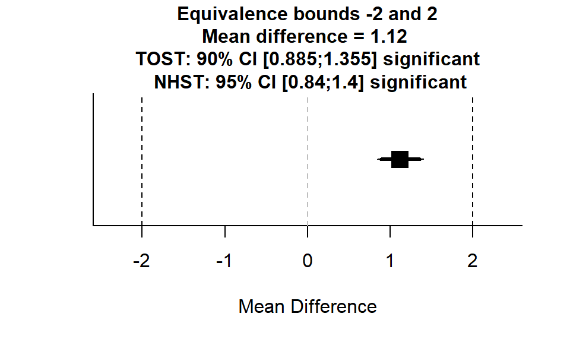

```
## TOST results:
##   t-value 1     p-value 1 t-value 2    p-value 2    df
## 1  21.82389 1.135529e-104 -6.158168 3.749734e-10 19998
##
## Equivalence bounds (raw scores):
##   low bound raw high bound raw
## 1            -2              2
##
## TOST confidence interval:
##   Lower Limit 90% CI raw Upper Limit 90% CI raw
## 1              0.8845569               1.354838
```

## TOST for the independent t-test

We get an output of regular NHST *t*-tests, as well as TOST *t*-tests - *t*-test (NHST) was significant - TOST was significant in both directions - i.e. statistically significant, but practically meaningless

## TOST for the independent t-test; effect sizes

```r
TOSTtwo(
  m1 = 100,
  m2 = 101,
  sd1 = 9,
  sd2 = 8.1,
  n1 = 192,
  n2 = 191,
  low_eqbound_d = -0.3,
  high_eqbound_d = 0.3,
  alpha = 0.05,
  var.equal = FALSE
  )
```

## TOST for the independent t-test; effect sizes

```
## Using alpha = 0.05 Welch's t-test was non-significant, t(377.2452) = -1.143038, p = 0.2537477
```

```
##
## Using alpha = 0.05 the equivalence test based on Welch's t-test  was significant, t(377.2452) = 1.792912, p = 0.03689397
```

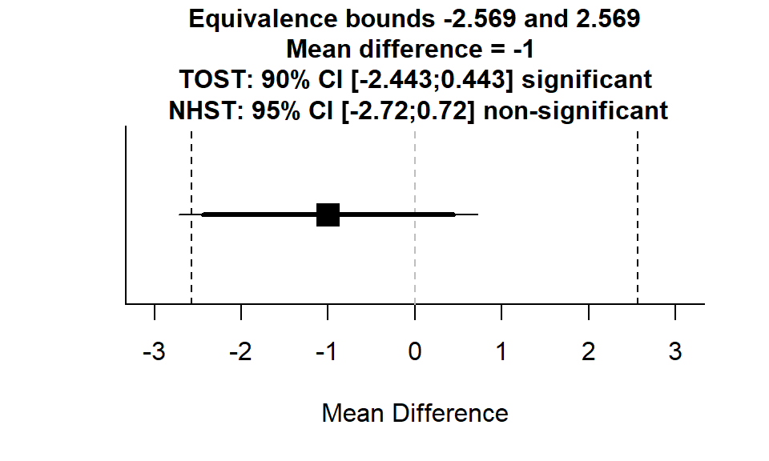

```
## TOST results:
##   t-value 1  p-value 1 t-value 2    p-value 2       df
## 1  1.792912 0.03689397 -4.078988 2.760588e-05 377.2452
##
## Equivalence bounds (Cohen's d):
##   low bound d high bound d
## 1        -0.3          0.3
##
## Equivalence bounds (raw scores):
##   low bound raw high bound raw
## 1      -2.56855        2.56855
##
## TOST confidence interval:
##   Lower Limit 90% CI raw Upper Limit 90% CI raw
## 1              -2.442562              0.4425618
```

## TOST for the independent t-test

- *t*-test was non-significant
- TOST was significant
- no significant difference, and groups are equivalent

This was a crash course in the TOST. Check Daniel Lakens' work for a primer on this.

## Understanding Problematic Design Choices

Final part of the course.

- Why do you need to consider pre-registration? It helps you to not fool yourself!
- We'll look at flexible analysis; specifically optional stopping
- Strength of NHST is when we stick to your plan.
- More freedom = increased type-I errors (dodgy conclusions commence!)

## Understanding Problematic Design Choices

- Run the optional stopping functions in your class script.
- Run a test with 30 people in each group. If it comes up non-significant, recruit another 10 and re-test.
- What happens to the number of *p*-values below the .05 threshold?
- Remember, under the null (assumed here), they should be evenly distributed (i.e. 5% below .05 \(\alpha\)-level)

```r
set.seed(100) # uncomment if you want different values each time
p_vals <- replicate(n = 1000, bias_test(30, 10))
mean(p_vals < .05)
```

```
## [1] 0.088
```

## Understanding Problematic Design Choices

### Optional Stopping (Without Correction)

Let's plot these *p*-values. They aren't evenly distributed! - Easy fix, **Bonferroni correction**: multiply your *p*-value by the number of times you tested.

## Understanding Problematic Design Choices

### Optional Stopping (Without Correction)

```r
p_plot <- ggplot() +
  geom_histogram(aes(p_vals),
                 binwidth = 0.05,
                 boundary = 0,
                 fill = "white",
                 colour = "black") +
  scale_x_continuous(limits = c(0, 1),
                     breaks = seq(from = 0, to = 1, by = 0.05)
                     ) +
  geom_vline(xintercept = 0.05, linetype = 2, colour = "red") +
  labs(x = "p-value") +
  theme(axis.text.x = element_text(size=8))
p_plot
```

## Understanding Problematic Design Choices

### Optional Stopping (Without Correction)

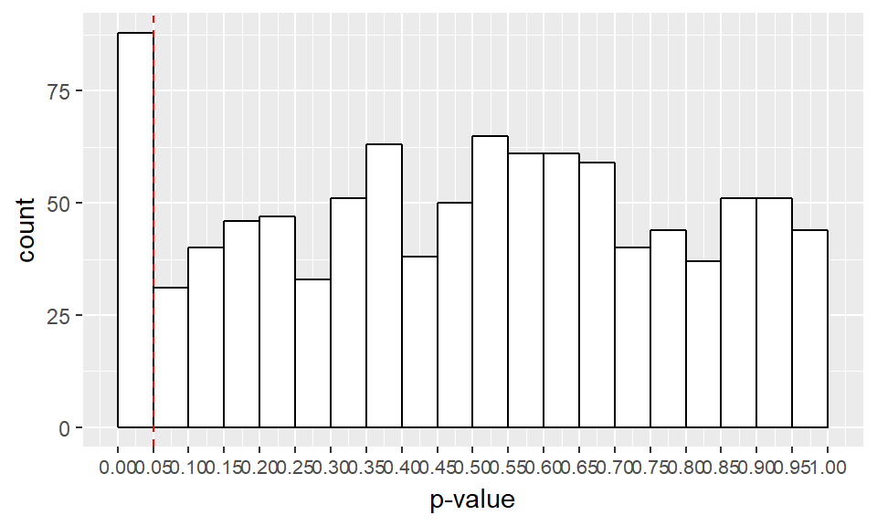

## Understanding Problematic Design Choices

The final lesson: good statistics can't save you from bad hypotheses.

- Run the function that tests for the probability of a positive result being a true effect
- Default parameters: 90% power, \(\alpha\)-level of 5%, chance of hypothesis being true is 1%.

```r
test_prob_hyp_true()
```

```
## [1] "There is a 15.38 % chance of a positive result being true."
```

## If You Get Stuck; My Favourite Covers

[figure not shown]